# Numero di campioni e tempi di analisi per il metodo CHEM0543d nell’anno 2024

# Introduzione

In questa esercitazione analizzeremo il numero di campioni e i tempi di analisi relativi a un metodo analitico specifico, nell’arco di un intero anno.

L’obiettivo è duplice:

- prendere confidenza con un flusso di lavoro tipico in R (download dei dati, pulizia, trasformazioni, aggregazioni);
- produrre una sintesi grafica che permetta di valutare l’andamento temporale del carico di lavoro e delle prestazioni analitiche.

Il documento è parametrizzato: modificando i parametri `method`, `target` e `year` è possibile riutilizzare lo stesso codice per analizzare metodi, con obiettivi diversi in anni diversi, senza dover intervenire manualmente sul resto del codice.

# Librerie utilizzate

Iniziamo caricando le librerie necessarie. Useremo:

- `readxl` per caricare i dati da file Excel;
- `data.table` per la gestione efficiente dei dati tabellari;
- `ggplot2` per la produzione dei grafici;
- `patchwork` per combinare più grafici in un’unica figura;
- `knitr` per generare tabelle all’interno di documenti.

Nel resto dell’esercitazione vedremo passo per passo il significato dei vari comandi, cercando di introdurre tutti i concetti che ci serviranno, man mano che li incontreremo.

```r
library(readxl)      # carica dati da file excel
library(data.table)  # manipola i dati
library(ggplot2)     # crea grafici
library(patchwork)   # unisce grafici
library(knitr)       # genera documenti e tabelle
```

# Download dei dati

Utilizzeremo dati simulati contenuti in due dataset:

- `dati_campioni.xlsx` è un foglio di calcolo contenente i dati relativi a misure effettuate in un laboratorio chimico con tre metodi differenti;
- `comuni_al.csv` è un file di testo con valori separati da virgole contenente informazioni sui comuni in provincia di Alessandria.

I due dataset sono in relazione attraverso i punti di prelievo dei campioni: un comune è associato a uno o più punti di prelievo, i quali sono associati a più campioni.

```r
misure <- read_excel("data/dati_campioni.xlsx") # leggo l'excel con readxl
misure <- data.table(misure)                    # converto a data.table
elenco_comuni <- fread("data/comuni_al.csv")    # anche con read.csv(), senza librerie esterne
```

# Esplorazione e pulizia dei dati

Dopo un primo controllo della struttura dei dati (ad esempio con `str()`), emergono alcune criticità tipiche dei dataset reali:

- le colonne di intestazioni contengono spazi e maiuscole;
- la data di campionamento è memorizzata come caratteri e non come oggetti `Date`;
- la colonna dei valori misurati è stata riportata come carattere;
- i valori e le note mancanti non sono correttamente codificate;
- i valori sono memorizzati come testo e non come numeri.

In questa sezione sistemiamo questi aspetti, rendendo il dataset coerente e pronto per le analisi successive. Questo passaggio è fondamentale: una buona pulizia dei dati semplifica enormemente le analisi successive e riduce il rischio di errori silenziosi, cioè errori che non producono messaggi ma risultati sbagliati.

```r
# dopo str() vedo che alcune cose non funzionano:
# - le intestazioni contengono caratteri scomodi
# - le date non sono date
# - L maiuscola di litri, non si può vedere
# - i valori mancanti non sono correttamente codificati
# - i numeri non sono numeri

# intestazioni minuscole e pulite
colnames(misure) <- gsub(pattern = " ", replacement = "_", colnames(misure))
colnames(misure) <- trimws(colnames(misure))
colnames(misure) <- colnames(misure) |> tolower()

# date come date e non come carattere
misure[, `:=` (
  data_campionamento = as.IDate(data_campionamento, format = "%d/%m/%Y"), # anche con as.Date e altri modi
  inizio_analisi = as.IDate(data_inizio_analisi),
  fine_analisi = as.IDate(data_fine_analisi),
  data_inizio_analisi = NULL,
  data_fine_analisi = NULL
  )]

# converto la L in l in udm
misure[, unita_di_misura := gsub("L", "l", unita_di_misura)]

# identifico i valori mancanti
misure[valore == "valore mancante", valore := NA]
misure[note == "-", note := NA]

# identifico i valori inferiori al limte di quantificazione:
# sono numeri positivi di cui conosco solo il limite superiore
# a seconda delle esigenze vengono sostituiti con un valore
# in questo caso usiamo la metà del limite di quantificazione
# e creo una colonna identificativa con
#    - FALSE per i valori inferiori al limite di quantificazione
#    - TRUE per i valori superiori al limite di quantificazione
misure[, quantificato := !grepl("^<", valore)]
misure[quantificato == FALSE, valore := limite_quantificazione / 2]

# finalmente converto a numeri
misure[, valore := as.numeric(valore)]
```

# Calcolo delle variabili di interesse

Una volta che i dati sono in ordine, costruiamo alcune variabili derivate:

- il mese di inizio dell’analisi, utile per le aggregazioni temporali
- il tempo di analisi, definito come la differenza tra la data di fine e la data di inizio analisi;
- il tempo di processamento complessivo, calcolato come differenza tra la data di fine e la data di campionamento.

Queste variabili ci permetteranno di studiare sia il volume di lavoro sia la distribuzione dei tempi nel corso dell’anno.

```r
# voglio vedere l'andamento mensile del numero di campioni e tempi di analisi:
# - calcolo i mesi
# - calcolo i tempi di analisi
# - calcolo i tempi di processamento

misure[, mese_inizio_analisi := month(inizio_analisi)]
misure[, tempo_processamento := fine_analisi - data_campionamento]
misure[, tempo_analisi := fine_analisi - inizio_analisi]
```

# Aggregazione mensile

Per rendere i dati più leggibili, aggreghiamo le informazioni a livello mensile.

In particolare, per ciascun mese calcoliamo:

- il numero di campioni analizzati;
- il tempo mediano di analisi;
- un intervallo dei tempi di analisi, escludendo i casi estremamente veloci e quelli estremamente lenti (10°–90° percentile).

Questo approccio consente di descrivere l’andamento tipico dei tempi di analisi senza essere troppo influenzati da valori anomali.

```r
# riassumo i tempi mensili di modo da ottenere:
# - il numero di campioni;
# - il tempo di analisi mediano
# - il tempo di analisi dell'80% dei campioni,
#   escludendo il 10% dei campioni velocissimi e
#   il 10% dei campioni lentissimi

riassunto <- misure[id_metodo == params$method,
              .(
                campioni = uniqueN(id_campione),
                analisi_mediana = median(tempo_analisi |> as.numeric()),
                analisi_veloce = quantile(tempo_analisi, 0.10),
                analisi_lenta = quantile(tempo_analisi, 0.90)
                ),
              by = .(mese_inizio_analisi)]

# i mesi non sono semplici numeri,
# sono elementi di un fattore ordinato
riassunto[, mese_inizio_analisi := factor(mese_inizio_analisi,
                                          levels = 1:12,
                                          labels = month.abb)]
```

# Visualizzazione dei risultati

Proseguiamo l’esercitazione con una rappresentazione grafica dei risultati:

- il primo grafico mostra l’andamento mensile del numero di campioni;
- il secondo grafico riassume la distribuzione dei tempi di analisi tramite mediana e percentili.

La combinazione dei due grafici permette di valutare visivamente se esiste una relazione tra carico di lavoro e tempi di analisi, e di individuare eventuali periodi critici dell’anno.

È importante ricordare che i grafici mostrano andamenti aggregati: eventuali anomalie o picchi andrebbero approfonditi tornando ai dati di dettaglio.

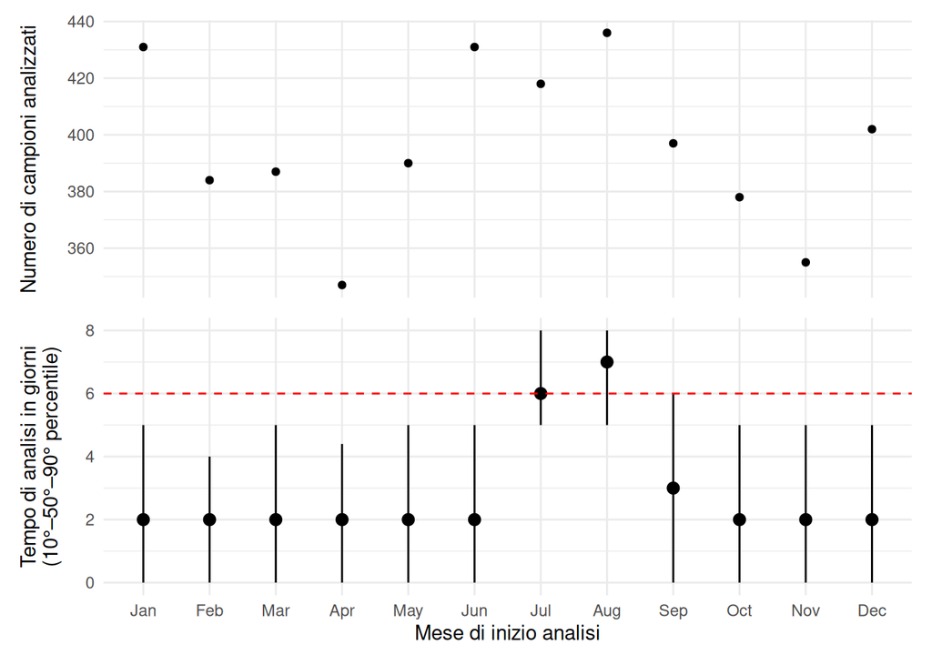

Figura 1: Andamento mensile del numero di campioni e tempi di analisi

```r
n_campioni <- ggplot(riassunto,
                     aes(x = mese_inizio_analisi,
                         y = campioni)) +
              geom_point() +
              scale_y_continuous(breaks = function(x) floor(pretty(x))) +
              labs(x = "Mese di inizio analisi",
                   y = "Numero di campioni analizzati") +
              theme_minimal()

tempi <- ggplot(riassunto,
                aes(x = mese_inizio_analisi,
                    ymin = analisi_veloce,
                    ymax = analisi_lenta,
                    y = analisi_mediana)) +
         geom_pointrange() +
         geom_hline(yintercept = params$target, col = "red", linetype = "dashed") +
         scale_y_continuous(breaks = function(x) floor(pretty(x))) +
         labs(x = "Mese di inizio analisi",
              y = "Tempo di analisi in giorni\n(10°–50°–90° percentile)") +
         theme_minimal()

n_campioni / tempi + plot_layout(axes = "collect")
```

Posso aggiungere anche del testo contenente dei calcoli in linea. Per esempio, per il metodo CHEM0543d, nel 2024 il numero dei campioni con tempi di analisi superiori all’obiettivo di 6 giorni è stato 1172, su un totale di 4756 campioni analizzati.

# Unire più fonti di dati

Spesso non tutti i dati che ci servono sono nello stesso file.

Nel nostro caso abbiamo caricato all’inizio dell’esercitazione `elenco_comuni` dove è disponibile la corrispondenza tra punti di campionamento e comuni. Combiniamo queste informazioni attraverso la funzione `merge` di `data.table`. In altri linguaggi come SQL, lo stesso concetto compare sotto il termine `join`.

```r
misure_completo <- merge(misure,                           # primo dataset
                         elenco_comuni,                    # secondo dataset
                         # sono in relazione attraverso una colonna che
                         # ha gli stessi valori in entrambi i dataset,
                         # ma ha nomi diversi
                         by.x = "punto_di_campionamento",  # nome nel primo dataset
                         by.y = "punti_di_misura")         # nome nel secondo dataset
```

Questo tipo di operazione è spesso critica in quanto si possono perdere o moltiplicare righe. Verifichiamo sempre con `nrow()` il numero di righe dei dataset di partenza e quelle del dataset unito.

In questo caso il numero di righe del dataset unito (`misure_completo`) combacia con quelle del dataset `misure`, mentre è molto maggiore del numero di righe del dataset `elenco_comuni`: alcuni punti di campionamento saranno stati indagati con più campioni.

Un’altra verifica spesso importante è che non ci siano punti di campionamento non associati a campioni o campioni non associati a un punto di campionamento.

# Tabelle

A questo punto possiamo riassumere il numero di campioni indagati per ogni comune, il numero di misure con esito non conforme e il numero di misure per il quale non è stato possibile consegnare un risultato a causa di problemi tecnici all’interno del laboratorio.

```r
riassunto_comune <- misure_completo[id_metodo == params$method,
                    .(
                      # questo è il numero di campioni
                      campioni_analizzati= uniqueN(id_campione),
                      # questo è il numero di misure non conformi
                      misure_non_conformi = sum(!conforme, na.rm = TRUE),
                      # questo è il numero di misure fallite
                      misure_fallite = sum(is.na(valore))
                    ),
                    by = denominazione_ita]

# cambio il nome delle colonne
riassunto_comune[, `:=` (
  comune = denominazione_ita,
  denominazione_ita = NULL
)]

# riordino le colonne
riassunto_comune <- riassunto_comune[order(-campioni_analizzati),
                      .(
                        comune,
                        campioni_analizzati,
                        misure_non_conformi,
                        misure_fallite
                       )]
```

Presento il risultato sotto forma di tabella.

```r
kable(riassunto_comune,
        col.names = c("Comune",
                      "Campioni analizzati",
                      "Misure non conformi",
                      "Misure fallite"))
```

Tabella 1: Riassunto dei campioni analizzati, delle misure non conformi e fallite per ogni comune.

| Comune | Campioni analizzati | Misure non conformi | Misure fallite |
| --- | --- | --- | --- |
| Alessandria | 656 | 139 | 0 |
| Tortona | 158 | 31 | 0 |
| Casale Monferrato | 136 | 22 | 0 |
| Ponzone | 110 | 22 | 1 |
| Bosio | 108 | 31 | 0 |
| Carrega Ligure | 88 | 19 | 0 |
| Spigno Monferrato | 88 | 23 | 0 |
| Novi Ligure | 88 | 15 | 0 |
| Voltaggio | 84 | 15 | 1 |
| Fabbrica Curone | 84 | 17 | 0 |
| Valenza | 78 | 11 | 1 |
| Sale | 74 | 18 | 0 |
| Castellazzo Bormida | 74 | 11 | 0 |
| Castelnuovo Scrivia | 74 | 24 | 0 |
| Cabella Ligure | 74 | 19 | 0 |
| Gavi | 70 | 17 | 0 |
| Bosco Marengo | 70 | 15 | 0 |
| Pareto | 66 | 17 | 0 |
| Borghetto di Borbera | 62 | 15 | 0 |
| Quargnento | 60 | 18 | 1 |
| Pozzolo Formigaro | 60 | 16 | 1 |
| Ovada | 56 | 6 | 0 |
| Sezzadio | 56 | 12 | 0 |
| Acqui Terme | 52 | 10 | 2 |
| Cassine | 52 | 11 | 0 |
| San Salvatore Monferrato | 52 | 12 | 0 |
| Molare | 52 | 15 | 0 |
| Predosa | 52 | 7 | 1 |
| Mongiardino Ligure | 48 | 8 | 0 |
| Arquata Scrivia | 48 | 15 | 0 |

[output cut: 157 more lines]